# Network Analysis with igraph

Keiichiro Ono

8/7/2014

## Basic Workflow 2: Working with igraph

by [Kazuhiro Takemoto](https://sites.google.com/site/kztakemoto/r-seminar-on-igraph---supplementary-information)*

Updated by [Keiichiro Ono](http://keiono.github.io/)

(The original tutorial was developed by Dr. Takemoto, and updated by Keiichiro Ono for cy-rest.)

[figure not shown]

[figure not shown]

## Introduction

Welcome to part 2 of the R tutorial. In this section, you will learn how to use Cytoscape with [igraph](http://igraph.org/r/).

### What is igraph?

igraph is one of the most popular network analysis toolkits for R/Python/C. It has a lot of graph analysis algorithms and utilities that Cytoscape does not have. If you use Cytoscape from igraph, you can use variety of network analysis functions in igraph and visualize the result with powerful visualization tools available in Cytoscape.

```r
# Basic setup
library(igraph)
library(RJSONIO)
library(httr)

port.number = 1234
base.url = paste("http://localhost:", toString(port.number), "/v1", sep="")
print(base.url)
```

```
## [1] "http://localhost:1234/v1"
```

## Loading Networks

There are many ways to import network data into igraph. In this example, let’s try to load text data as Data Frame, and then convert it into igraph object.

```r
# Load list of edges as Data Frame
network.df <- read.table("data/eco_EM+TCA.txt")

# Convert it into igraph object
network <- graph.data.frame(network.df,directed=T)

# Remove duplicate edges & loops
g.tca <- simplify(network, remove.multiple=T, remove.loops=T)

# Name it
g.tca$name = "Ecoli TCA Cycle"
```

### Convert igraph object into JSON

As you learned in the first tutorial, basic data exchange format between Cytoscape and external tools is Cytoscape.js JSON. To send igraph object to Cytoscape, you need to convert it into JSON:

```r
# This function will be published as a part of utility package, but not ready yet.
source('toCytoscape.R')

# Convert it into Cytosccape.js JSON
cygraph <- toCytoscape(g.tca)
```

### Visualize it in Cytoscape

Now you are ready to visualize your data in Cytoscape. It’s very straightforward:

```r
send2cy <- function(cygraph) {
  network.url = paste(base.url, "networks", sep="/")
  res <- POST(url=network.url, body=cygraph, encode="json")
  network.suid = unname(fromJSON(rawToChar(res$content)))
  print(network.suid)

  # Apply Visual Style and Circular Layout
  apply.layout.url = paste(base.url, "apply/layouts/circular", toString(network.suid), sep="/")
  apply.style.url = paste(base.url, "apply/styles/default%20black", toString(network.suid), sep="/")

  res <- GET(apply.layout.url)
  res <- GET(apply.style.url)
}

#send2cy(cygraph)
```

If you want to visualize your network in igraph, obviously it is possible:

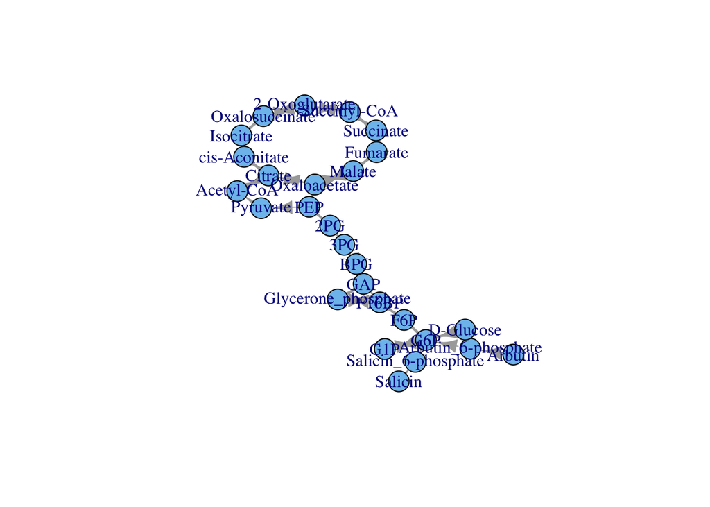

```r
plot(g.tca,vertex.label=V(g.tca)$name)
```

This is a static image and there is no interactivity. In contrast, the result you see in the Cytoscape applicaiton window should look like this:

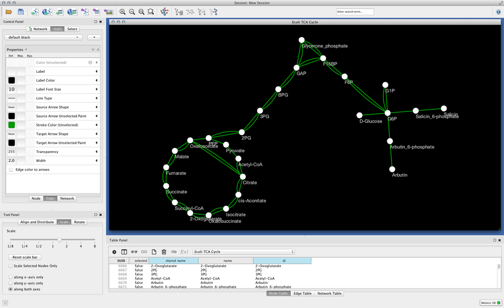

You can tweak your result interactively with fully-featured network visualization workbench. And of course, you can modify your [Visual Styles](http://wiki.cytoscape.org/Cytoscape_3/UserManual/Styles) programmatically or manually.

…Which one do you like?

### Find Shortest Path

- Find path from *D-Glucose* to *2-Oxoglutarate*

```r
paths <- get.all.shortest.paths(g.tca,"D-Glucose","2-Oxoglutarate",mode="out")

# Nodes in the first path
print(V(g.tca)[paths$res[[1]]])
```

```
## Vertex sequence:
##  [1] "D-Glucose"      "G6P"            "F6P"            "F16BP"
##  [5] "GAP"            "BPG"            "3PG"            "2PG"
##  [9] "PEP"            "Pyruvate"       "Acetyl-CoA"     "Citrate"
## [13] "cis-Aconitate"  "Isocitrate"     "Oxalosuccinate" "2-Oxoglutarate"
```

```r
# Add new attribute "path" and set value 1 for this path
V(g.tca)[paths$res[[1]]]$path <- 1

# Edges in the path
print(E(g.tca,path=paths$res[[1]]))
```

```
## Edge sequence:
##
## [15] D-Glucose      -> G6P
## [24] G6P            -> F6P
## [19] F6P            -> F16BP
## [17] F16BP          -> GAP
## [26] GAP            -> BPG
## [10] BPG            -> 3PG
## [5]  3PG            -> 2PG
## [4]  2PG            -> PEP
## [41] PEP            -> Pyruvate
## [42] Pyruvate       -> Acetyl-CoA
## [7]  Acetyl-CoA     -> Citrate
## [14] Citrate        -> cis-Aconitate
## [50] cis-Aconitate  -> Isocitrate
## [31] Isocitrate     -> Oxalosuccinate
## [38] Oxalosuccinate -> 2-Oxoglutarate
```

```r
# Add path attribute
E(g.tca, path=paths$res[[1]])$path <- 1
```

### Understanding *Styles* in Cytoscape

In igraph *plot* function, you need to specify actual visual property values directly. For example, if you want to paint the path found in the previous section in red, you need to set actual color (red) for each edge in the path. Instead, Cytoscape used a mapping mechanism called **Visual Style** and you can reuse the mapping instructions for multiple networks. For more details, please read the [manual](http://wiki.cytoscape.org/Cytoscape_3/UserManual/Styles).

#### Visualizing Paths

**The biggest difference between igraph and Cytoscape is that Cytoscape does not set visual property values, such as colors, shapes, or size, directly**.

**And you can reuse this for other visualizations**.

```r
# Name of this new style
style.name = "Path Visualization"

# Defaults
def.node.color <- list(
  visualProperty = "NODE_FILL_COLOR",
  value = "#FFFFFF"
)

def.node.border.width <- list(
  visualProperty = "NODE_BORDER_WIDTH",
  value = 0
)

def.edge.target.arrow <- list(
  visualProperty="EDGE_TARGET_ARROW_SHAPE",
  value="ARROW"
)

defaults <- list(def.node.color, def.node.border.width,def.edge.target.arrow)

# Visual Mappings
mappings = list()

pair1 = list(
  key = "1",
  value = "green"
)

discrete.mappings = list(pair1)

node.color = list(
  mappingType="discrete",
  mappingColumn="path",
  mappingColumnType="Integer",
  visualProperty="NODE_FILL_COLOR",
  map = discrete.mappings
)

node.label = list(
  mappingType="passthrough",
  mappingColumn="name",
  mappingColumnType="String",
  visualProperty="NODE_LABEL"
)

mappings = list(node.color, node.label)

style <- list(title=style.name, defaults = defaults, mappings = mappings)
style.JSON <- toJSON(style)

print(style.JSON)
```

```
## [1] "{\n \"title\": \"Path Visualization\",\n\"defaults\": [\n {\n \"visualProperty\": \"NODE_FILL_COLOR\",\n\"value\": \"#FFFFFF\" \n},\n{\n \"visualProperty\": \"NODE_BORDER_WIDTH\",\n\"value\":      0 \n},\n{\n \"visualProperty\": \"EDGE_TARGET_ARROW_SHAPE\",\n\"value\": \"ARROW\" \n} \n],\n\"…
```

```r
style.url = paste(base.url, "styles", sep="/")
POST(url=style.url, body=style.JSON, encode = "json")
```

```
## Response [http://localhost:1234/v1/styles]
##   Status: 200
##   Content-type: application/json
## {"title": "Path Visualization_1"}
```

```r
cygraph.updated <- toCytoscape(g.tca)
send2cy(cygraph.updated)
```

```
## [1] 416
```